# 2017-09-11-probability_1

#### 수식이 깨질 경우 새로고침을 눌러주세요.

## Probability for Data-Science-13

## 다변수 확률 모형 ②

- Categorical (Multinoulli)
- Multinomial
- **✓Dirichlet**
- Multivariate Gaussian Normal

## Dirichlet distribution (디리클레 분포)

> 디리클레 분포(Dirichlet distribution)는 베타 분포의 다차원 확장
> - 베타 분포 → 0과 1사이의 값을 가지는 단일(univariate) 확률 변수의 베이지안 모형에 사용된다.
> - 디리클레 분포는 0과 1사이의 사이의 값을 가지는 다변수(multivariate) 확률 변수의 베이지안 모형에 사용된다.

> > 다만, 디리클레 분포는 **다변수 확률 변수들의 합이 1**이되어야 한다는 제한 조건을 가진다.

#### 참고 : [베타분포](https://namyoungkim.github.io/python/probability/statistics/2017/09/05/probability.html)

> **디리클레 분포의 확률 밀도 함수** $$ f(x_1, x_2, \cdots, x_K) = \frac{1}{\mathrm{B}(\boldsymbol\alpha)} \prod_{i=1}^K x_i^{\alpha_i - 1} $$

$$ \begin{eqnarray} 단,\;\; \mathrm{B}(\boldsymbol\alpha) &=& \frac{\prod_{i=1}^K \Gamma(\alpha_i)} {\Gamma\bigl(\sum_{i=1}^K \alpha_i\bigr)} \\ \\&=& \frac{\Gamma(\alpha_1)\cdots\Gamma(\alpha_K)}{\Gamma(\alpha_1+\cdots+\alpha_K)} \end{eqnarray} $$$$또한,\;\;\; (0 \leq x_i \leq 1)\;이며\;\; \sum_{i=1}^{K} x_i = 1 $$$$ 이\;\; 식에서 \;\; \boldsymbol\alpha =\; (\alpha_1, \alpha_2, \ldots, \alpha_K)는 \;\;디리클레 \;\;분포의 \;\;모수 \;\;벡터이다. $$

> **ex)** K=3인 디리클레 분포를 따르는 확률 변수는 다음과 같은 값을 샘플로 가질 수 있다.

$$(1, 0, 0), \;\;\;(0.5, 0.5, 0),\;\;\; (0.2, 0.3, 0.5)$$

### 베타 분포와 디리클레 분포의 관계

> 베타 분포는 $K=2$ 인 디리클레 분포라고 볼 수 있다.

$$ f(x_1, x_2) = \frac{1}{\mathrm{B}(\boldsymbol\alpha)} \prod_{i=1}^2 x_i^{\alpha_i - 1} $$

$$ \begin{eqnarray} f(x_1, x_2) &=& \frac{1}{\mathrm{B}(\boldsymbol\alpha)} \prod_{i=1}^2 x_i^{\alpha_i - 1} \\ &=& \frac{1}{\mathrm{B}(\alpha_1,\alpha_2)} x_1^{\alpha_1 - 1}x_2^{\alpha_2 - 1} \end{eqnarray} $$

$$ 여기서\;\; x_2 \;=\; 1 - x_1\; 이고, \alpha_1= a,\;\; \alpha_2= b\; 라 \;\;하면 $$

$$ \begin{eqnarray} \frac{1}{\mathrm{B}(\alpha_1,\alpha_2)} x_1^{\alpha_1 - 1}x_2^{\alpha_2 - 1} &=& \frac{1}{\mathrm{B}(a,b)} x_1^{a - 1}(1-x_1)^{b - 1} \\ \\&=& \text{Beta}(x_1;a,b) \end{eqnarray} $$

### 디리클레 분포의 모멘트 특성

> **기대값** $$ \begin{eqnarray} E[x_k] &=& \dfrac{\alpha_k}{\boldsymbol\alpha} \\ &=& \dfrac{\alpha_k}{\sum\alpha_k} \end{eqnarray} $$

$$ 위에서\;\; 보듯이\;\; \boldsymbol{\alpha} = \sum\alpha_k $$$$ 기대값\;\; 공식을\;\; 보면\;\; 모수인\;\; \boldsymbol\alpha \;=\; (\alpha_1,\; \alpha_2,\; \ldots,\; \alpha_K)는\\ (x_1, x_2, \ldots, x_K)\;\; 중\;\; 어느\;\; 수가\;\; 더\;\; 크게\;\; 나올\;\; 가능성이\;\; 높은\;지를\;\; 결정하는\;\; 형상\;\; 인자(shape \;factor)임을\;\; 알\;\; 수\;\; 있다.\;\;\\ 모든\;\; \alpha_i값이\;\; 동일하면\;\; 모든\;\; x_i의\;\; 분포가\;\; 같아진다. $$

> **모드**

$$ \dfrac{\alpha_k - 1}{\boldsymbol\alpha - K}$$

> **분산**

$$\text{Var}[x_k] =\dfrac{\alpha_k(\boldsymbol\alpha - \alpha_k)}{\boldsymbol\alpha^2(\boldsymbol\alpha + 1)}$$

$$ 또한\;\; 분산\;\; 공식을\;\; 보면\;\; \boldsymbol\alpha의\;\; 절대값이\;\; 클수록\;\; 분산이\;\; 작아진다.\\ 즉,\;\; 어떤\;\; 특정한\;\; 값이\;\; 나올\;\; 가능성이\;\; 높아진다. $$

### 디리클레 분포의 응용

$$ 다음과\;\; 같은\;\; 문제를\;\; 보자.\;\; 이\;\; 문제는\;\; K=3이고\;\; \alpha_1 = \alpha_2 = \alpha_3\; 인\;\; Dirichlet\;\; 분포의\;\; 특수한\;\; 경우이다. $$

$$ x,\; y,\; z가\;\; 난수일\;\; 때,\;\; 항상\; x\;+\;y\;+\;z \;=\; 1이\;\; 되도록\;\; 하려면?\;\; (단,\;\; x,\;y,\;z는\;\; 균등하게\;\; 뽑아야\;\; 하며,\;\; x>0\;, y>0\;, z>0) $$

> **Sol**

> 3차원 디리클레 문제는 3차원 공간 상에서 (1,0,0), (0,1,0), (0,0,1) 세 점을 연결하는 정삼각형 면위의 점을 생성하는 문제라고 볼 수 있다.

```python
# -*- coding: utf-8 -*-

import seaborn as sns
import pandas as pd
import scipy as sp
import matplotlib as mpl
import matplotlib.pylab as plt
import numpy as np
%matplotlib inline
```

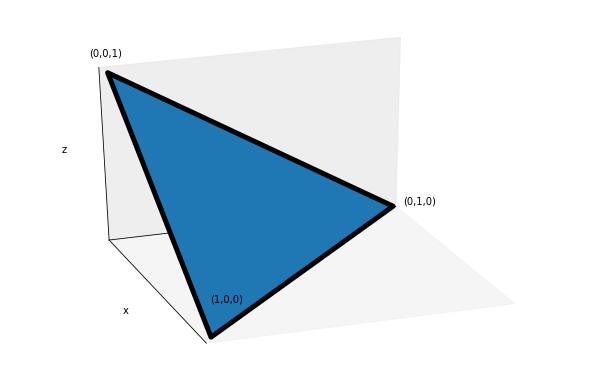

```python
from mpl_toolkits.mplot3d import Axes3D
from mpl_toolkits.mplot3d.art3d import Poly3DCollection

# 3차원 도화지를 꺼내라.
fig = plt.figure(figsize=(8,5))
ax = Axes3D(fig)


x = [1,0,0]
y = [0,1,0]
z = [0,0,1]

# x,y,z벡터의 각 원소를 zip으로 묶어서, 3차 좌표로 변환
## zip으로 좌표를 묶은 후 리스트가 두개가 있어야 그래프가 그려진다. 차원을 맞춰 주어야한다.
verts = [list(zip(x, y, z))]
ax.add_collection3d(Poly3DCollection(verts, edgecolor="k", lw=5, alpha=0.4))

ax.text(1, 0, 0, "(1,0,0)", position=(0.7,0.1))
ax.text(0, 1, 0, "(0,1,0)", position=(0,1.04))
ax.text(0, 0, 1, "(0,0,1)", position=(-0.2,0))

ax.set_xlabel("x")
ax.set_ylabel("y")
ax.set_zlabel("z")

ax.set_xticks([])
ax.set_yticks([])
ax.set_zticks([])

ax.view_init(30, -20)
tmp_planes = ax.zaxis._PLANES
# set origin ( http://stackoverflow.com/questions/15042129/changing-position-of-vertical-z-axis-of-3d-plot-matplotlib )
ax.yaxis._PLANES = (tmp_planes[2], tmp_planes[3],
                    tmp_planes[0], tmp_planes[1],
                    tmp_planes[4], tmp_planes[5])
ax.zaxis._PLANES = (tmp_planes[2], tmp_planes[3],
                    tmp_planes[0], tmp_planes[1],
                    tmp_planes[4], tmp_planes[5])
plt.show()
```

### 주의!

```python
x = [1,0,0]
y = [0,1,0]
z = [0,0,1]

verts_1 = [zip(x, y, z)]
verts_2 = list(zip(x, y, z))
```

```python
verts_1
```

```
[<zip at 0x10f071288>]
```

```python
verts_2
```

```
[(1, 0, 0), (0, 1, 0), (0, 0, 1)]
```

#### 위에서 보듯이 리스트와 zip은 같이 다녀야 한다!

```python
x = [1,0,0]
y = [0,1,0]
z = [0,0,1]

# x,y,z벡터의 각 원소를 zip으로 묶어서, 3차 좌표로 변환
## zip으로 좌표를 묶은 후 리스트가 두개가 있어야 그래프가 그려진다. 차원을 맞춰 주어야한다.
verts_3 = [list(zip(x, y, z))]
```

```python
verts_3
```

```
[[(1, 0, 0), (0, 1, 0), (0, 0, 1)]]
```

### 그래프를 그릴 때, 위 처럼 리스트가 2개가 있어야한다. 차원을 맞춰줘야 한다!

#### 다음 함수는 생성된 점들을 2차원 삼각형 위에서 볼 수 있도록 그려주는 함수이다.

```python
def plot_triangle(X, kind):
    n1 = np.array([1, 0, 0])
    n2 = np.array([0, 1, 0])
    n3 = np.array([0, 0, 1])

    # n1과 n2의 중점
    n12 = (n1 + n2)/2
    m1 = np.array([1, -1, 0])
    m2 = n3 - n12

    # 노말라이징해서 단위벡터로 변환
    m1 = m1/np.linalg.norm(m1)
    m2 = m2/np.linalg.norm(m2)

    X1 = (X-n12).dot(m1)
    X2 = (X-n12).dot(m2)

    g = sns.jointplot(X1, X2, kind=kind, xlim=(-0.8,0.8), ylim=(-0.45,0.9))
    g.ax_joint.axis("equal")
    plt.show()
```

> 만약 이 문제를 단순하게 생각하여 서로 독립인 0과 1사이의 유니폼 확률 변수를 3개 생성하고 이들의 합이 1이 되도록 크기를 정규화(normalize)하면

> 다음 그림과 같이 삼각형의 중앙 근처에 많은 확률 분포가 집중된다. 즉, 확률 변수가 골고루 분포되지 않는다.

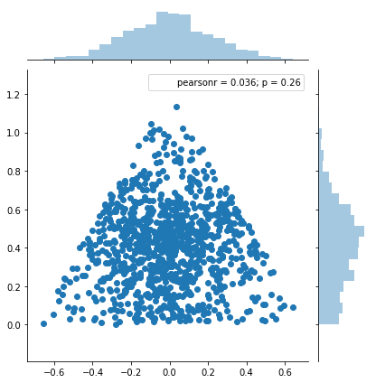

```python
X1 = np.random.rand(1000, 3)
X1 = X1/X1.sum(axis=1)[:, np.newaxis]
plot_triangle(X1, kind="scatter")
```

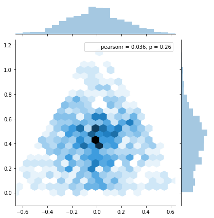

```python
plot_triangle(X1, kind="hex")
```

#### 그러나 alpha=(1,1,1)인 디리클레 분포는 다음과 같이 골고루 샘플을 생성한다.

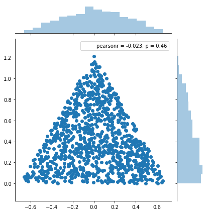

```python
X2 = sp.stats.dirichlet((1,1,1)).rvs(1000)
plot_triangle(X2, kind="scatter")
```

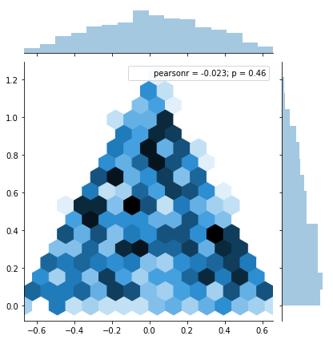

```python
plot_triangle(X2, kind="hex")
```

### alpha가 (1,1,1) 이 아닌 경우

> 다음과 같이 특정 위치에 분포가 집중되도록 할 수 있다.

> 이 특성을 이용하면 다항 분포의 모수를 추정하는 베이지안 추정 문제에 응용할 수 있다.

```python
def project(x):
    n1 = np.array([1, 0, 0])
    n2 = np.array([0, 1, 0])
    n3 = np.array([0, 0, 1])
    n12 = (n1 + n2)/2
    m1 = np.array([1, -1, 0])
    m2 = n3 - n12
    m1 = m1/np.linalg.norm(m1)
    m2 = m2/np.linalg.norm(m2)
    return np.dstack([(x-n12).dot(m1), (x-n12).dot(m2)])[0]

def project_reverse(x):
    n1 = np.array([1, 0, 0])
    n2 = np.array([0, 1, 0])
    n3 = np.array([0, 0, 1])
    n12 = (n1 + n2)/2
    m1 = np.array([1, -1, 0])
    m2 = n3 - n12
    m1 = m1/np.linalg.norm(m1)
    m2 = m2/np.linalg.norm(m2)
    return x[:,0][:, np.newaxis] * m1 + x[:,1][:, np.newaxis] * m2 + n12

eps = np.finfo(float).eps * 10
X = project([[1-eps,0,0], [0,1-eps,0], [0,0,1-eps]])
```

```python
import matplotlib.tri as mtri
triang = mtri.Triangulation(X[:,0], X[:,1], [[0, 1, 2]])
refiner = mtri.UniformTriRefiner(triang)
triang2 = refiner.refine_triangulation(subdiv=6)
XYZ = project_reverse(np.dstack([triang2.x, triang2.y, 1-triang2.x-triang2.y])[0])
```

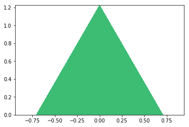

```python
# alpha = (1,1,1) 일 때
pdf = sp.stats.dirichlet((1,1,1)).pdf(XYZ.T)

# 삼각 등고선을 그려라.
plt.tricontourf(triang2, pdf)
plt.axis("equal")
plt.show()
```

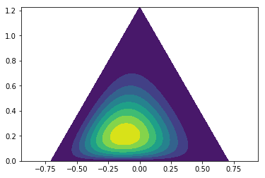

```python
# (3, 4, 2) 일 때
pdf = sp.stats.dirichlet((3,4,2)).pdf(XYZ.T)
plt.tricontourf(triang2, pdf)
plt.axis("equal")
plt.show()
```

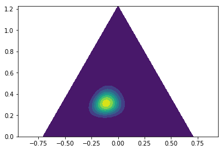

```python
# (16, 24, 14) 일 때
pdf = sp.stats.dirichlet((16,24,14)).pdf(XYZ.T)
plt.tricontourf(triang2, pdf)
plt.axis("equal")
plt.show()
```

### alpha 값에 따라 자료의 집중도가 달라진다.

### 모수의 추정

$$ \hat{\theta}\; : \;\;\; Hyper\;\; Parameter\;라고도\;\; 하며,\;\; 분포의\;\; 파라미터를\;\; 추정하는\;\; 파라미터이다. $$

> 베타분포
> - a = b = 1
> - a, b를 조작해서 어느 부분의 값을 많이 나오게 할 수 있다.

> Parameter가 많을 수록 비모수적 방법을 사용한다.
> - seaborn histogram을 사용.

>   > 자료의 분포를 히스토그램으로 구간별로 쌓아서 그리도록 한다. 앞에서 해왔던 **시뮬레이션의 방법과 동일**하다.

> 모수적 방법(Parameteric) VS 비모수적 방법(Non-Parameteric)
> - 일반적으로 파라미터가 5개, 10개가 넘어가면 비모수라고 한다.